# tutorial_reliability

## Characterizing Individual Differences

This is a **introduction** for individual variation/distance field map and reliability

**Goal**: mapping individual differences

First, let’s think of a scenario that we are trying to characterize some individual features that are fixed or relatively stable (e.g. fingerprint). Let’s also assume that have some perfect measurements can characterize the features very well. Then, mapping individual difference would be very easy (e.g. directly calculate the distance or variation of our measurements between individuals). However, when mapping the brain, the current world is not perfect. We face two main challenges.

**Challenges**:

- The individual features are not fixed. Within-individual variation of the features always exist.
- The measurements are not perfectly characterizing the features (e.g. bias, noise, etc.)

**Consequence**:

- The observed between-individual difference (e.g. distance, variation) contains 1) the within-individual variation, and 2) the measurement noises/biases.

**We need**:

- Separate the within-individual variation from the observed between-individual difference
- If individual features (e.g. brain function) change, to what extend (at what time-scale), the features are stable.
- Improve the measurement; reduce noises and biases.

**How**:

### Field map (Distance field map and Variation field map)

The toy example includes 2 repetitions in 10 participants. Figure 3a shows the pairwise symmetric distance matrix between each of the measures, ordered by participants. The block-diagonal matrices indicate how different the repeated measures are within participants, whereas off-diagonal elements represent the dissimilarity of measures between participants.

By plotting the observed between-individual elements along the y-axis against the within-individual value on the x-axis (Figure 3b). Each between-individual element for a row or column in the distance matrix can be represented by an array of dots in the distance space. It’s important to note that the x=y line in this space represents the case that within-individual distance equals to the observed between-individual distance. The dots above the x=y line (i.e. x<y, shaded zone) represent the cases that the difference between repetitions within individuals is lower than distance observed between individuals. By counting the percentage of dot columns that fully fall above the x<y zone (i.e. within-individual distance < between-individual distance ) as compared to the number of individuals (i.e. total number of dot columns), we can calculate the percentage that the individual subjects can be successfully differentiated from the group (i.e. identification rate, a.k.a. fingerprinting). In the toy example, 3 out of 10 dot columns are above the x=y line and resulting fingerprinting=0.3 (Figure 3c). If more dots fall above the x<y zone, the repetitions within individuals are more likely similar to one another but distant from other individuals. Instead of counting the percentage of the dot columns above x=y line, discriminability measures the percentage of dots above the x<y zone as compared to the total number of dots.

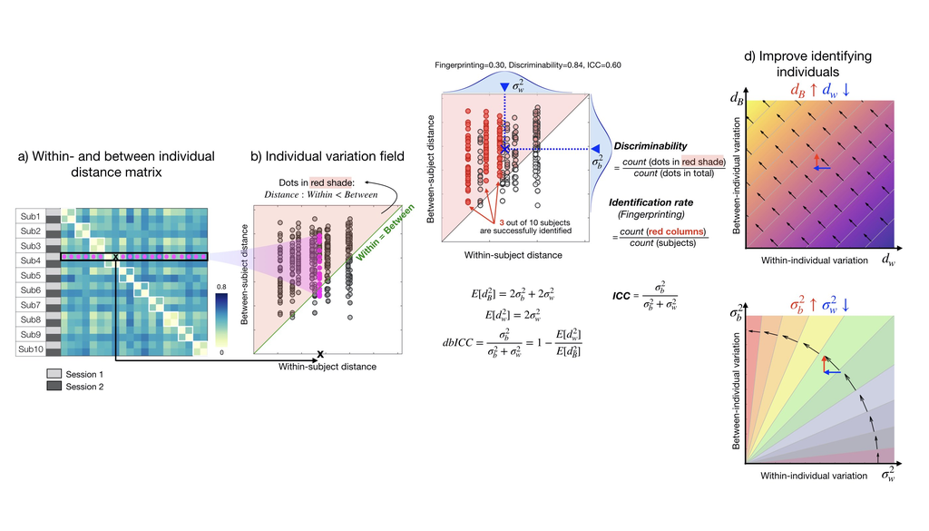

Fig 1